# Homework 9

We are going to explore the zeros of the zeroth bessel function of first kind, by using the bisection and Newton-Raphson methods and then plotting the comparison between them.

First we import the libraries and save the function on a certain interval just for a few points,

```python
import matplotlib.pylab as plt
import numpy as np
from scipy import special
x=np.linspace(0,10,10)
y=special.j0(x)
```

So the plot goes as

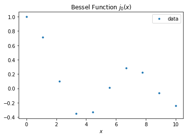

```python
fig=plt.figure()
ax=fig.add_subplot(111)
ax.plot(x,y,'.',label='data')
ax.set_title("Bessel Function $j_0(x)$")
ax.set_xlabel("$x$")
plt.legend()
plt.show()
```

To find the zeros, we define the function and its first derivative

```python
def func(x):
    return special.j0(x)
def dfunc(x):
    return -special.j1(x)
```

Exploring the data, we define 3 intervals where the zeros are,

```python
intervals=[[1,3],[4.5,6.5],[8,10]]
```

Then, we define the bisection and Newton-Raphson methods to return lists of the 10 firsts values,

```python
def bisec(f,an,bn):
    pn=[]
    for i in range(10):
        pm=(an+bn)/2.
        if (f(an)*f(pm)>0):
            an=pm
        else:
            bn=pm
        pn.append(pm)
    return pn
def Newton(f0,df0,xi):
    xn=[]
    for i in range(10):
        xi-=f0(xi)/df0(xi)
        xn.append(xi)
    return xn
```

We Use both methods for the three intervals and plot the solutions.

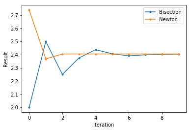

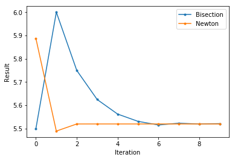

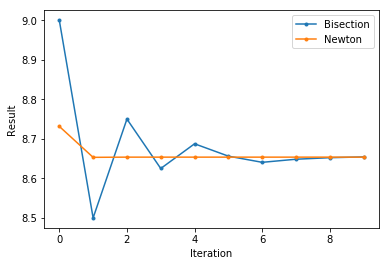

```python
final_newton=[]
final_bisection=[]
for i in intervals:
    xmin=i[0]
    xmax=i[1]
    data=bisec(func,xmin,xmax)
    data2=Newton(func,dfunc,xmin)
    plt.plot(data,'.-',label='Bisection')
    plt.plot(data2,'.-',label='Newton')
    plt.xlabel('Iteration')
    plt.ylabel('Result')
    plt.legend()
    plt.show()
    final_newton.append(data2[-1])
    final_bisection.append(data[-1])
```

### Conclusions

Plotting this, we can clearly see that, both methods converge to the same result, but the Newton's method does it way faster.

To test our solutions, we can use the `SciPy` solutions as if they were the real data.

```python
real=special.jn_zeros(0,3)
bis=np.array(final_bisection)
new=np.array(final_newton)
```

So, one can see the percentual error, so that

```python
print((new-real)/real)
print((bis-real)/real)
```

```
[0. 0. 0.]
[-2.19842431e-04  2.54754495e-04  6.57476286e-05]
```

And as you can see, the Newton's method has exact the same result!.